# Sophia_temp-analysis

Allison Davis and Sophia McKelvey

2024-02-22

# Temperature experiment

*Purpose:* Our interest lies in whether sexually selected traits have deleterious effects on males’ ability to tolerate change. This is from an observation of males dying when sampling during hot months but females surviving fine.

*Hypothesis:* (1) Sexually selected traits decrease resistance to environmental change across species; and (2) courtship displays further decrease resistance to environmental change within a species.

*Predictions:* - Males of fish with elaborate traits have a narrower thermal tolerance–i.e. lower thermal maximums and higher thermal minimums–compared to females of these species. - Males of fish without elaborate traits will have a similar tolerance to females of the same species. - Males performing courtship displays have a narrower thermal tolerance compared to males using coercion (within swordtails).

# Data

We performed crtical temperature assays in which we exposed fish in groups of about 8 to gradually increasing or decreasing temperatures. Individual critical temperatures were recorded at the time of loss of equilibrium (LOE). We will then compare these temperatures, and the total thermal tolerance (CTmax-CTmin), both within species and between species.

To work with the data, we first need to create a github repository, upload a csv of our data, and then pull the data down into this Rmd to analyse it.

You first need to call you data from the internet (github) in order to run stats in Rstudio. Your data should be saved as a csv file, and uploaded to your github repository (github project). On github, click on your project, click on the csv file, then hit “raw” –you will need to copy the html of the raw file to use in Rstudio.

To pull your data into Rstudio, you will need to use the following functions/packages: library(), curl package, curl(), read.csv()

- If you haven’t done so already, install the curl package. You can install a package in two ways:
  1. use `install.packages()` with the name of the package in the brackets
  2. go to your packages tab in the lower right corner (Files Plots **Packages** Help Viewer), hit install, and type in the name of the package before hitting the install button again.

```r
#load in the curl package
library(curl)
#pull the data from the internet using your html and assign a name
rawdata_1 <- curl("https://raw.githubusercontent.com/sophia-m0823/TestRStudio/main/Temp%20ID%20-%20Completed%20Data.csv")

#force your data to be read as a csv
rawdata_1 <- read.csv(rawdata_1, header = TRUE, sep = ",", stringsAsFactors = TRUE)
head(rawdata_1)
```

```
##        Species   Mating Size.cat    Sex     Name CTmax.num CTmin.num CTmax.C
## 1 X. nigrensis courting    large   male   Charms         5         2   36.06
## 2 X. nigrensis courting    large   male Cinnamon         6         3   36.25
## 3 X. nigrensis courting    large   male   Crunch         3         5   35.94
## 4 X. nigrensis     <NA>      reg female    Lucky         4         1   35.88
## 5 X. nigrensis     <NA>      reg female    Toast         1         4   32.13
## 6 X. nigrensis     <NA>      reg female Cherrios         2         6   33.25
##   CTmin.C T.tot Size.mm
## 1    9.81 26.25    34.0
## 2    9.38 26.87    32.8
## 3    9.19 26.75    33.0
## 4   10.56 25.32    21.3
## 5    9.31 22.82    23.9
## 6    8.56 24.69    24.8
```

Now we want to make sure your data was pulled correctly, and we also want to create separate data frames for each of the species. This way we can do stats on four data frames: raw data (original file we pulled from the internet), sailfin (all the info but just for P. latipinna), mosquitofish (all the info but just for G. affinis), and swordtails (all the info but just for the X. nigrensis).

For this step, you will need: head(), data frame selection (aka data frame[data frame$name …..])

- Make sure you assign a new name for your new data frames! If you keep the name the same for all three data frames, R will overwrite (aka erase) your data!
- For more info on how to select from a data frame, see: https://cran.r-project.org/web/packages/lessR/vignettes/Extract.html#:~:text=The%20most%20general%20way%20to,d%5Brows%2C%20columms%5D%20.

```r
#check the head of your raw dataframe to make sure it was read in correctly
#NOTE: whenever you read in a csv, R automatically adds X.U.FEFF to the first column. This is normal!

sailfin_1 <- rawdata_1[rawdata_1$Species =="P. latipinna",]   ### first = row, then column


#create a dataframe for mosquitofish by selecting data from your raw dataframe with G. affinis as the species.
mosquito_1 <- rawdata_1[rawdata_1$Species =="G. affinis",]

#create a dataframe for swordtails by selecting data from your raw dataframe with X. nigrensis as the species.
swordtail_1 <- rawdata_1[rawdata_1$Species =="X. nigrensis",]
```

# Analysis

## Summary stats

Now we get to the fun part -actually analyzing our data! While most people want to jump right in to the most complicated stat models, it’s actually better practice to get an idea of what your data look like. Getting summary statistics (mean, median, mode etc) and visualizing your data give you an idea of how your data relate to each other. This will make the conclusions from the more complicated stats easier to understand.

So let’s begin with summary statistics. For this you will need: rstatix package, get_summary_stats()

- Make sure to install the rstatix package. See the beginning of this Rmd on how to install.
- The summary stats you want are: mean, standard deviation, median, and interquartile range.
- For more details on how to use get_summary_stats() see: https://www.datanovia.com/en/lessons/wilcoxon-test-in-r/#summary-statistics-2
  - ex: get_summary_stats(weight, type =“median”, data=mice)
    - the %>% used on the website requires another package (tidyverse), but is just specifying the data frame to use; if you’re not familiar with tidyverse, instead use data=name in function OR specify by mice$weight.
- You may need to switch from a ‘wide’ format dataframe to a ‘long’ format dataframe in order from some of these functions to work. For this you will use the ‘pivot_longer()’ and ‘pivot_wider()’ functions from tidyverse (don’t worry, if you’re not familar with tidyverse, you can just follow the info in the link). For more info on how to use, see: https://tidyr.tidyverse.org/articles/pivot.html

```r
#load in the rstatix package

library(rstatix)
#get summary statistics for all data
summary(rawdata_1)
```

```
##          Species         Mating    Size.cat      Sex          Name
##  G. affinis  :17   coercive :17   large: 7   female:39   Bella  : 3
##  P. latipinna:32   courting :23   reg  :64   male  :40   Jess   : 3
##  X. nigrensis:30   NA's     :39   small: 8               Amy    : 2
##                                                          Beth   : 2
##                                                          Brad   : 2
##                                                          Chad   : 2
##                                                          (Other):65
##    CTmax.num       CTmin.num        CTmax.C         CTmin.C
##  Min.   :1.000   Min.   :1.000   Min.   :32.13   Min.   : 2.060
##  1st Qu.:2.500   1st Qu.:2.500   1st Qu.:35.78   1st Qu.: 6.565
##  Median :4.000   Median :4.000   Median :37.63   Median : 7.880
##  Mean   :4.481   Mean   :4.481   Mean   :37.05   Mean   : 7.597
##  3rd Qu.:6.000   3rd Qu.:6.000   3rd Qu.:38.44   3rd Qu.: 9.380
##  Max.   :9.000   Max.   :9.000   Max.   :39.75   Max.   :11.130
##
##      T.tot          Size.mm
##  Min.   :22.12   Min.   :17.45
##  1st Qu.:26.03   1st Qu.:22.30
##  Median :29.62   Median :29.70
##  Mean   :29.45   Mean   :28.36
##  3rd Qu.:32.34   3rd Qu.:33.35
##  Max.   :36.44   Max.   :38.70
##
```

```r
#get summary statistics for the sailfin data  #NOTE: want to get an idea of how each species looks, so we'll separate them.
summary(sailfin_1)
```

```
##          Species         Mating    Size.cat      Sex          Name
##  G. affinis  : 0   coercive : 0   large: 0   female:16   Jess   : 2
##  P. latipinna:32   courting :16   reg  :32   male  :16   Amy    : 1
##  X. nigrensis: 0   NA's     :16   small: 0               August : 1
##                                                          Bella  : 1
##                                                          Bert   : 1
##                                                          Beth   : 1
##                                                          (Other):25
##    CTmax.num      CTmin.num       CTmax.C         CTmin.C          T.tot
##  Min.   :1.00   Min.   :1.00   Min.   :36.81   Min.   :3.560   Min.   :28.43
##  1st Qu.:2.75   1st Qu.:2.75   1st Qu.:37.97   1st Qu.:6.160   1st Qu.:30.13
##  Median :4.50   Median :4.50   Median :38.44   Median :7.250   Median :31.25
##  Mean   :4.50   Mean   :4.50   Mean   :38.44   Mean   :6.884   Mean   :31.56
##  3rd Qu.:6.25   3rd Qu.:6.25   3rd Qu.:39.06   3rd Qu.:7.827   3rd Qu.:32.84
##  Max.   :8.00   Max.   :8.00   Max.   :39.75   Max.   :9.250   Max.   :35.50
##
##     Size.mm
##  Min.   :26.70
##  1st Qu.:31.50
##  Median :33.70
##  Mean   :33.12
##  3rd Qu.:35.20
##  Max.   :38.70
##
```

```r
#get summary statistics for the mosquitofish data
summary(mosquito_1)
```

```
##          Species         Mating   Size.cat      Sex         Name
##  G. affinis  :17   coercive :9   large: 0   female:8   Ahoy   : 1
##  P. latipinna: 0   courting :0   reg  :17   male  :9   Cheez  : 1
##  X. nigrensis: 0   NA's     :8   small: 0              Dave   : 1
##                                                        Fred   : 1
##                                                        George : 1
##                                                        Itz    : 1
##                                                        (Other):11
##    CTmax.num       CTmin.num        CTmax.C         CTmin.C
##  Min.   :1.000   Min.   :1.000   Min.   :34.62   Min.   :2.060
##  1st Qu.:3.000   1st Qu.:3.000   1st Qu.:37.56   1st Qu.:3.250
##  Median :5.000   Median :5.000   Median :38.13   Median :4.560
##  Mean   :4.765   Mean   :4.765   Mean   :37.58   Mean   :4.949
##  3rd Qu.:7.000   3rd Qu.:7.000   3rd Qu.:38.44   3rd Qu.:6.690
##  Max.   :9.000   Max.   :9.000   Max.   :38.81   Max.   :8.000
##
##      T.tot          Size.mm
##  Min.   :27.57   Min.   :19.80
##  1st Qu.:30.06   1st Qu.:21.00
##  Median :33.69   Median :24.80
##  Mean   :32.63   Mean   :25.68
##  3rd Qu.:35.00   3rd Qu.:30.80
##  Max.   :36.44   Max.   :33.40
##
```

```r
#get summary statistics for the swordtail data
summary(swordtail_1)
```

```
##          Species         Mating    Size.cat      Sex          Name
##  G. affinis  : 0   coercive : 8   large: 7   female:15   Bella  : 2
##  P. latipinna: 0   courting : 7   reg  :15   male  :15   Brad   : 2
##  X. nigrensis:30   NA's     :15   small: 8               Amy    : 1
##                                                          Ava    : 1
##                                                          Babs   : 1
##                                                          Beth   : 1
##                                                          (Other):22
##    CTmax.num      CTmin.num       CTmax.C         CTmin.C           T.tot
##  Min.   :1.00   Min.   :1.00   Min.   :32.13   Min.   : 8.560   Min.   :22.12
##  1st Qu.:2.25   1st Qu.:2.25   1st Qu.:35.00   1st Qu.: 9.310   1st Qu.:24.70
##  Median :4.00   Median :4.00   Median :35.59   Median : 9.908   Median :25.57
##  Mean   :4.30   Mean   :4.30   Mean   :35.27   Mean   : 9.860   Mean   :25.41
##  3rd Qu.:6.00   3rd Qu.:6.00   3rd Qu.:35.98   3rd Qu.:10.363   3rd Qu.:26.39
##  Max.   :8.00   Max.   :8.00   Max.   :36.25   Max.   :11.130   Max.   :27.12
##
##     Size.mm
##  Min.   :17.45
##  1st Qu.:21.35
##  Median :22.40
##  Mean   :24.79
##  3rd Qu.:26.32
##  Max.   :38.50
##
```

### Summary plots

While numbers are great, a picture is often easier to understand. So let’s graph out our data to get a better idea of what’s going on. Box plots are a good graph to use, since it will show us the median and range of the data.

We’ll focus on each species separately, then look at them all together. Our main goal is to see if males and females differ in their thermal tolerance.

You may need to switch from a ‘wide’ format dataframe to a ‘long’ format dataframe in order from some of these functions to work. For this you will use the ‘pivot_longer()’ and ‘pivot_wider()’ functions from tidyverse (don’t worry, if you’re not familar with tidyverse, you can just follow the info in the link). For more info on how to use, see: https://tidyr.tidyverse.org/articles/pivot.html

For this you will use: boxplot(), line() [can also use ggplot if you’re more comfortable with that]

- For more info on boxplot() see: https://www.statmethods.net/graphs/boxplot.html
- For more info on line() see: https://r-graph-gallery.com/line-plot.html
- We want our boxplots to temperature by sex for within species, and temperature by sex AND species for between species. When we want to display our y value (temp) by two x values (sex and species), we denote this as y~x1*x2. We’ll repeat this for our Tmax, Tmin, and Ttot temperature vaues.
- Remember to add x and y lables!

```r
library(ggplot2)
library(tidyr)
library(tidyverse)
#create a box plot showing max temperature by sex in sailfin
head(sailfin_1)
```

```
##         Species   Mating Size.cat    Sex    Name CTmax.num CTmin.num CTmax.C
## 16 P. latipinna courting      reg   male   Onion         2         2   38.50
## 17 P. latipinna courting      reg   male Cheddar         5         3   39.06
## 18 P. latipinna courting      reg   male     Bun         7         7   39.44
## 19 P. latipinna courting      reg   male  Pickle         8         1   39.75
## 20 P. latipinna     <NA>      reg female  Tomato         1         4   38.19
## 21 P. latipinna     <NA>      reg female   Patti         3         6   38.69
##    CTmin.C   T.tot Size.mm
## 16  4.6875 33.8125    33.3
## 17  4.6900 34.3700    34.2
## 18  4.6300 34.8100    32.9
## 19  4.6900 35.0600    34.3
## 20  4.5600 33.6300    32.4
## 21  4.6900 34.0000    32.8
```

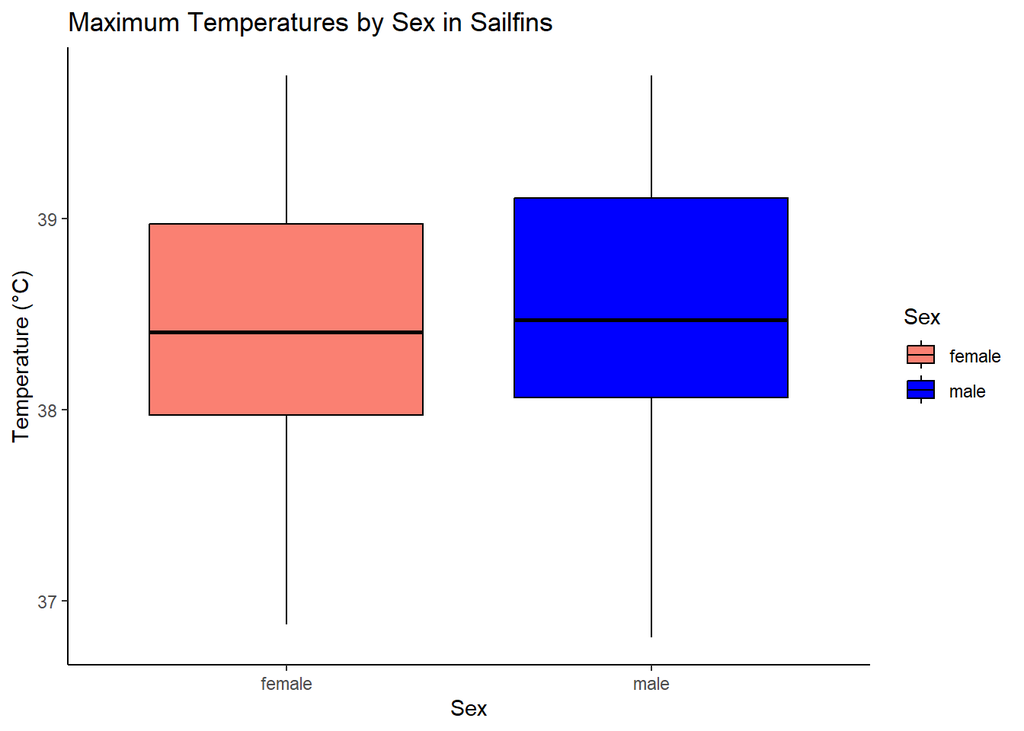

```r
sailfin_boxplot1 <- ggplot(data = sailfin_1,
                           aes(x = Sex,
                               y = CTmax.C,
                               fill = Sex)) +
  geom_boxplot(color = "black") +
  labs(
    title = "Maximum Temperatures by Sex in Sailfins",
    x = "Sex",
    y = "Temperature (°C)"
  ) +
  theme_classic() +
  scale_fill_manual(values = c("salmon", "blue"))


print(sailfin_boxplot1)
```

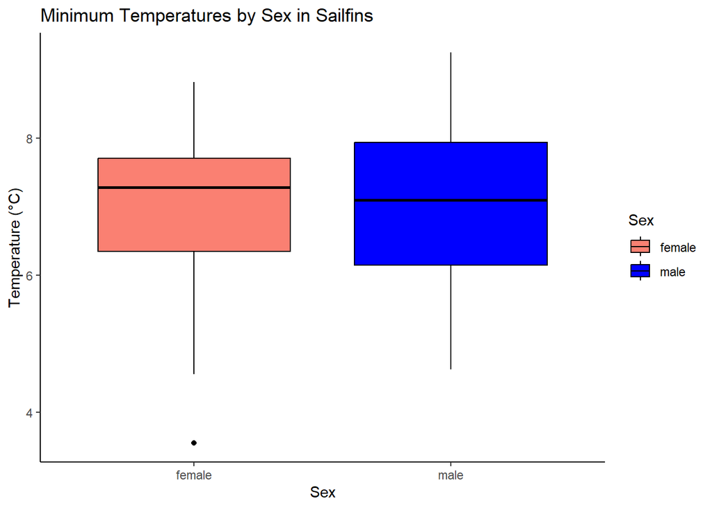

```r
# repeat for min temperature, and Ttot
sailfin_boxplot2 <- ggplot(data = sailfin_1,
                           aes(x = Sex,
                               y = CTmin.C,
                               fill = Sex)) +
  geom_boxplot(color = "black") +
  labs(
    title = "Minimum Temperatures by Sex in Sailfins",
    x = "Sex",
    y = "Temperature (°C)"
  ) +
  theme_classic() +
  scale_fill_manual(values = c("salmon", "blue"))

print(sailfin_boxplot2)
```

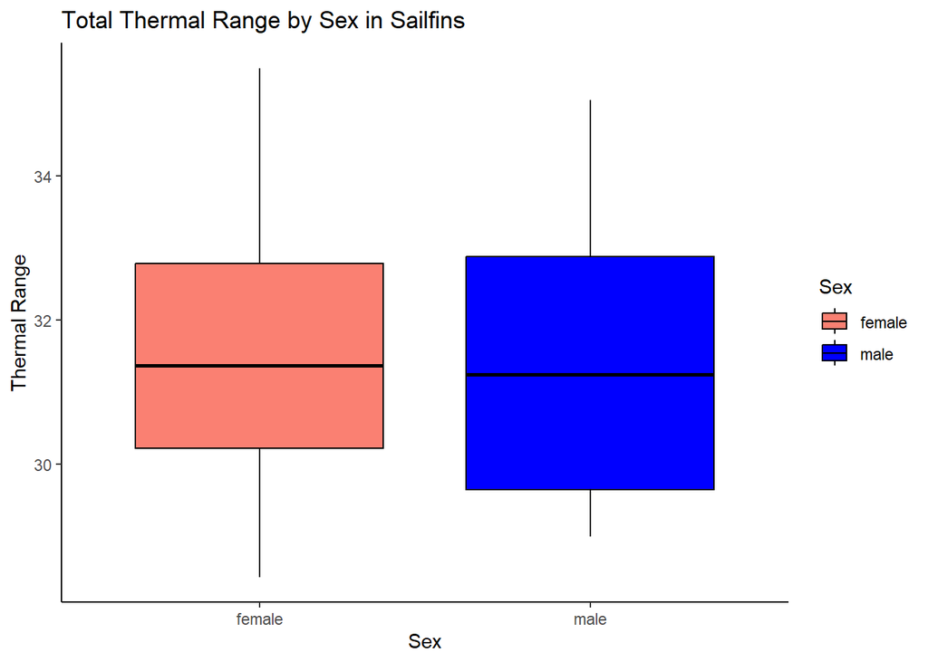

```r
sailfin_boxplot3 <- ggplot(data = sailfin_1,
                           aes(x = Sex,
                               y = T.tot,
                               fill = Sex)) +
  geom_boxplot(color = "black") +
  labs(
    title = "Total Thermal Range by Sex in Sailfins",
    x = "Sex",
    y = "Thermal Range"
  ) +
  theme_classic() +
  scale_fill_manual(values = c("salmon", "blue"))

print(sailfin_boxplot3)
```

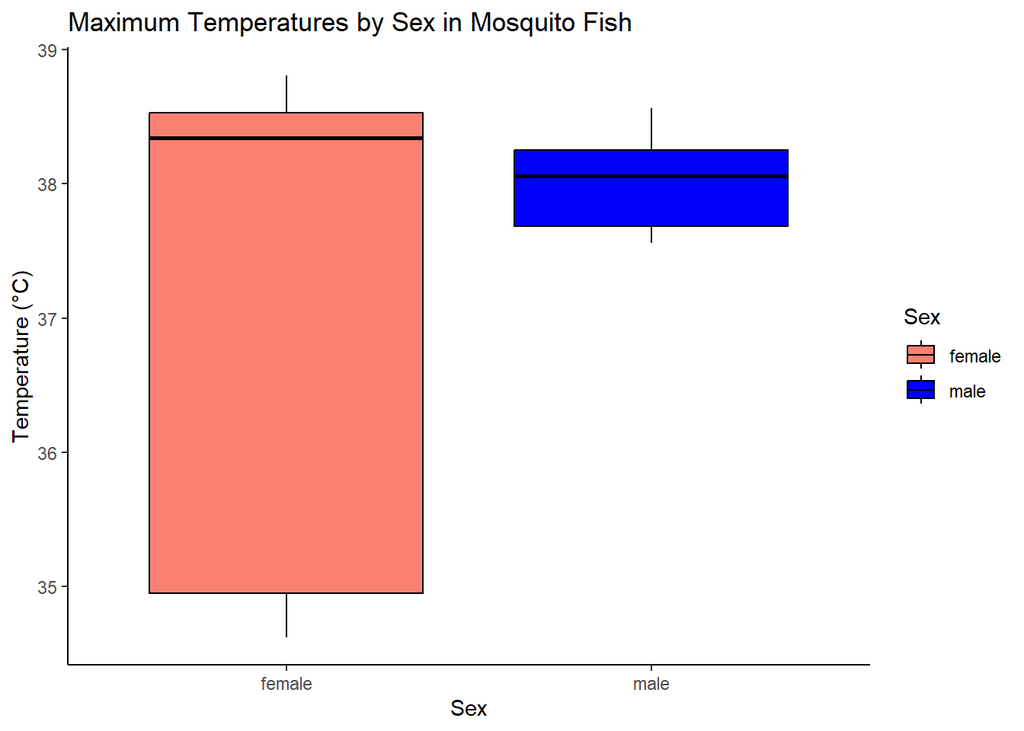

```r
#create a box plot showing max temperature by sex in mosquitofish
mosquito_boxplot1 <- ggplot(data = mosquito_1,
                           aes(x = Sex,
                               y = CTmax.C,
                               fill = Sex)) +
  geom_boxplot(color = "black") +
  labs(
    title = "Maximum Temperatures by Sex in Mosquito Fish",
    x = "Sex",
    y = "Temperature (°C)"
  ) +
  theme_classic() +
  scale_fill_manual(values = c("salmon", "blue"))

print(mosquito_boxplot1)
```

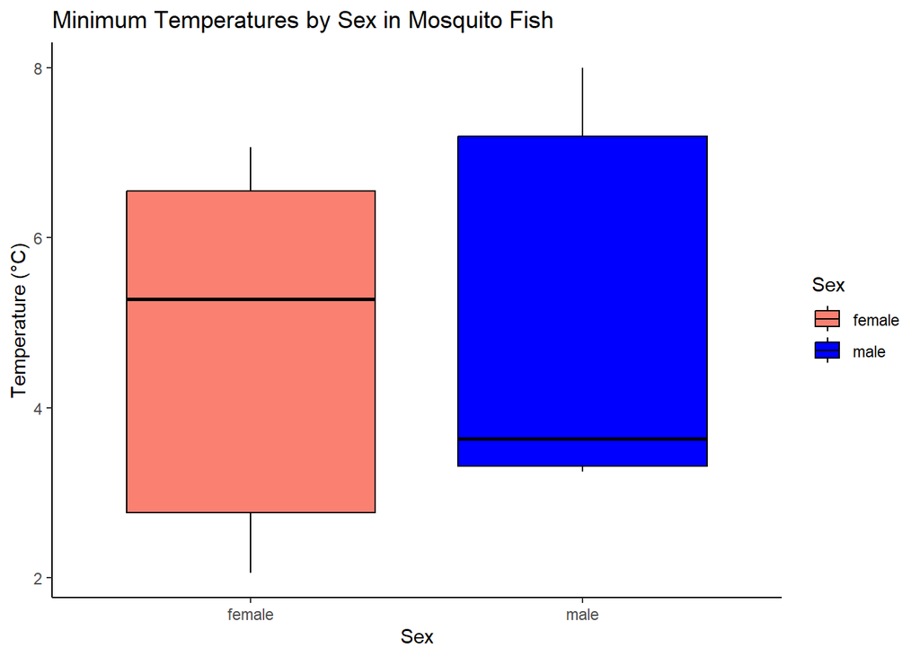

```r
# repeat for min temperature, and Ttot
mosquito_boxplot2 <- ggplot(data = mosquito_1,
                           aes(x = Sex,
                               y = CTmin.C,
                               fill = Sex)) +
  geom_boxplot(color = "black") +
  labs(
    title = "Minimum Temperatures by Sex in Mosquito Fish",
    x = "Sex",
    y = "Temperature (°C)"
  ) +
  theme_classic() +
  scale_fill_manual(values = c("salmon", "blue"))

print(mosquito_boxplot2)
```

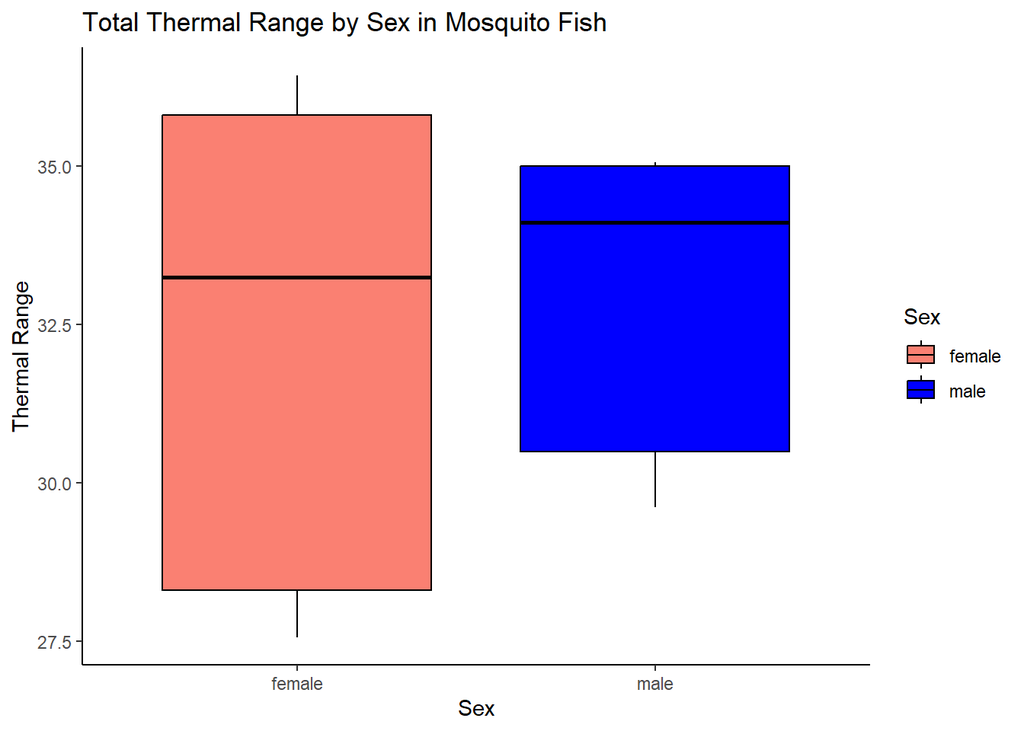

```r
mosquito_boxplot3 <- ggplot(data = mosquito_1,
                           aes(x = Sex,
                               y = T.tot,
                               fill = Sex)) +
  geom_boxplot(color = "black") +
  labs(
    title = "Total Thermal Range by Sex in Mosquito Fish",
    x = "Sex",
    y = "Thermal Range"
  ) +
  theme_classic() +
  scale_fill_manual(values = c("salmon", "blue"))

print(mosquito_boxplot3)
```

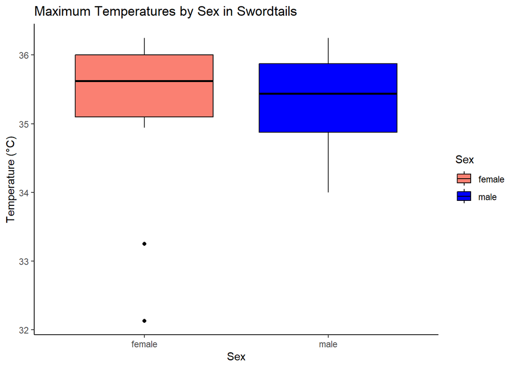

```r
#create a box plot showing max temperature by sex in swordtail

swordtail_boxplot1 <- ggplot(data = swordtail_1,
                           aes(x = Sex,
                               y = CTmax.C,
                               fill = Sex)) +
  geom_boxplot(color = "black") +
  labs(
    title = "Maximum Temperatures by Sex in Swordtails",
    x = "Sex",
    y = "Temperature (°C)"
  ) +
  theme_classic() +
  scale_fill_manual(values = c("salmon", "blue"))

print(swordtail_boxplot1)
```

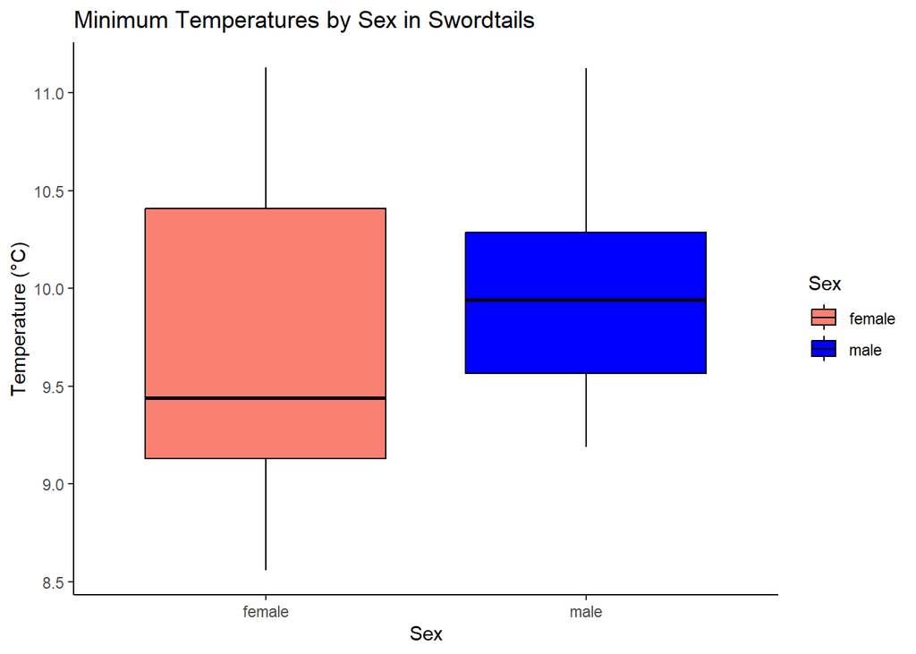

```r
# repeat for min temperature, and Ttot

swordtail_boxplot2 <- ggplot(data = swordtail_1,
                           aes(x = Sex,
                               y = CTmin.C,
                               fill = Sex)) +
  geom_boxplot(color = "black") +
  labs(
    title = "Minimum Temperatures by Sex in Swordtails",
    x = "Sex",
    y = "Temperature (°C)"
  ) +
  theme_classic() +
  scale_fill_manual(values = c("salmon", "blue"))

print(swordtail_boxplot2)
```

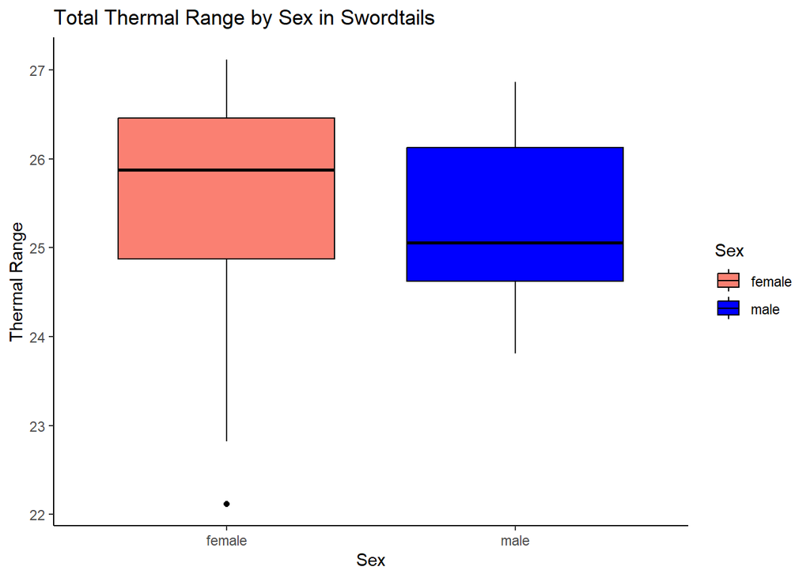

```r
swordtail_boxplot3 <- ggplot(data = swordtail_1,
                           aes(x = Sex,
                               y = T.tot,
                               fill = Sex)) +
  geom_boxplot(color = "black") +
  labs(
    title = "Total Thermal Range by Sex in Swordtails",
    x = "Sex",
    y = "Thermal Range"
  ) +
  theme_classic() +
  scale_fill_manual(values = c("salmon", "blue"))

print(swordtail_boxplot3)
```

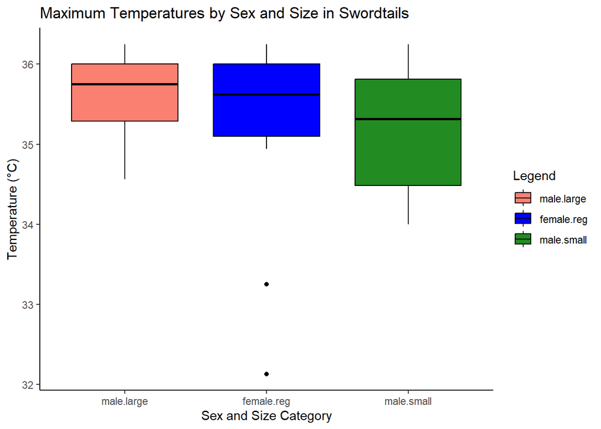

```r
#create a box plot showing max temperature by sex AND size category in swordtails
swordtail_boxplot4 <- ggplot(data = swordtail_1,
                             aes(x = interaction(Sex, Size.cat),
                                 y = CTmax.C,
                                 fill = interaction(Sex, Size.cat))) +
  geom_boxplot(color = "black") +
  labs(
    title = "Maximum Temperatures by Sex and Size in Swordtails",
    x = "Sex and Size Category",
    y = "Temperature (°C)",
    fill = "Legend"
  ) +
  theme_classic() +
  scale_fill_manual(values = c("salmon", "blue", "forestgreen"))

print(swordtail_boxplot4)
```

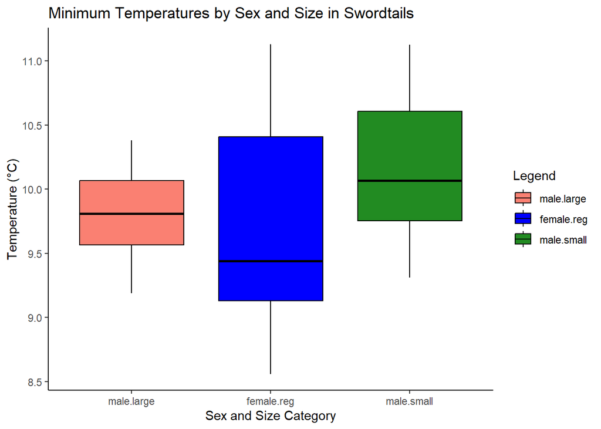

```r
# repeat for min temperature, and Ttot
swordtail_boxplot5 <- ggplot(data = swordtail_1,
                             aes(x = interaction(Sex, Size.cat),
                                 y = CTmin.C,
                                 fill = interaction(Sex, Size.cat))) +
  geom_boxplot(color = "black") +
  labs(
    title = "Minimum Temperatures by Sex and Size in Swordtails",
    x = "Sex and Size Category",
    y = "Temperature (°C)",
    fill = "Legend"
  ) +
  theme_classic() +
  scale_fill_manual(values = c("salmon", "blue", "forestgreen"))

print(swordtail_boxplot5)
```

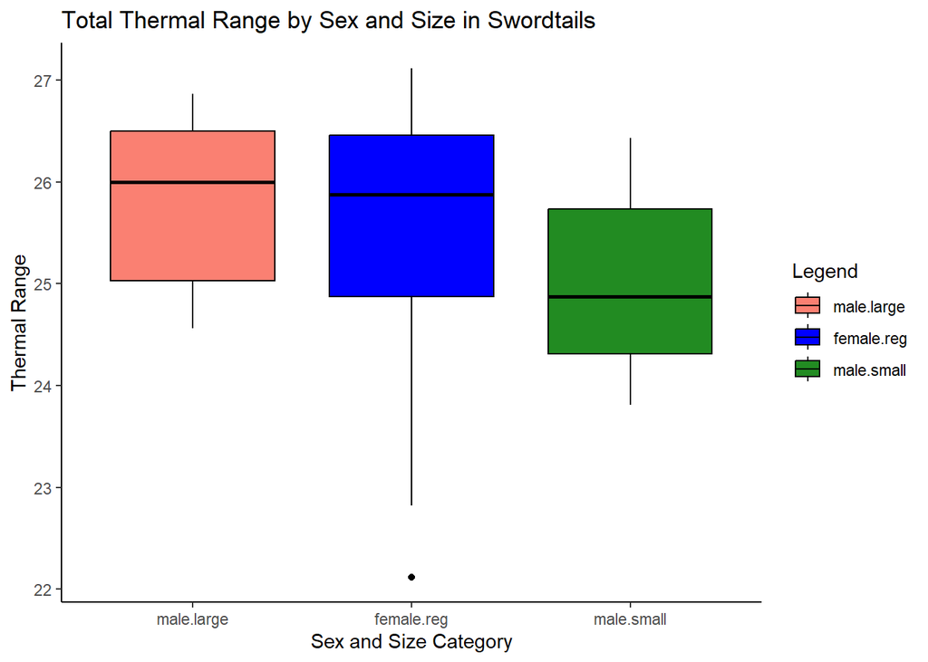

```r
swordtail_boxplot6 <- ggplot(data = swordtail_1,
                             aes(x = interaction(Sex, Size.cat),
                                 y = T.tot,
                                 fill = interaction(Sex, Size.cat))) +
  geom_boxplot(color = "black") +
  labs(
    title = "Total Thermal Range by Sex and Size in Swordtails",
    x = "Sex and Size Category",
    y = "Thermal Range",
    fill = "Legend"
  ) +
  theme_classic() +
  scale_fill_manual(values = c("salmon", "blue", "forestgreen"))

print(swordtail_boxplot6)
```

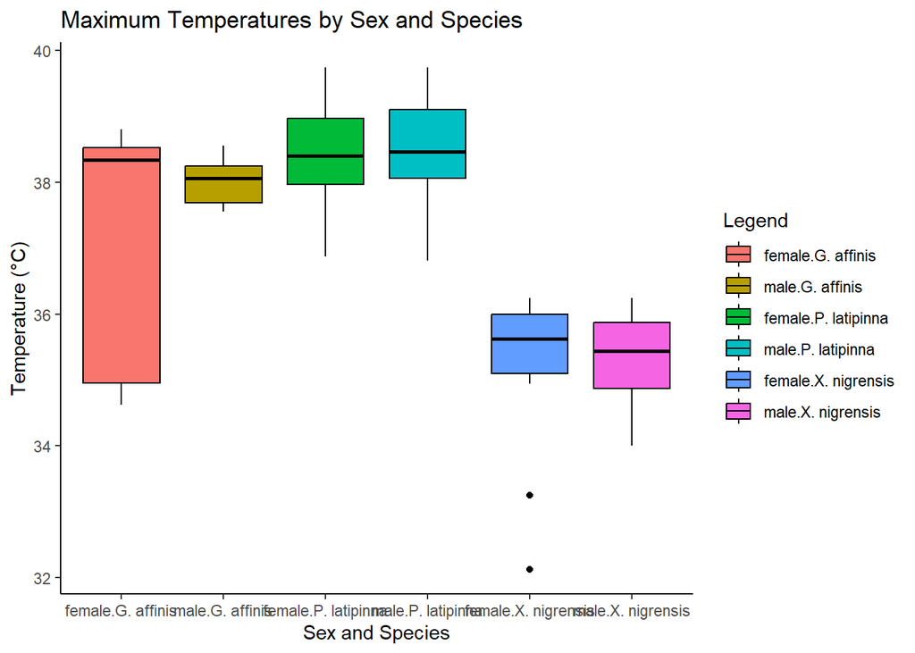

```r
#create a box plot showing max temperature by sex AND species (all)
all_boxplot1 <- ggplot(data = rawdata_1,
                             aes(x = interaction(Sex, Species),
                                 y = CTmax.C,
                                 fill = interaction(Sex, Species))) +
  geom_boxplot(color = "black") +
  labs(
    title = "Maximum Temperatures by Sex and Species",
    x = "Sex and Species",
    y = "Temperature (°C)",
    fill = "Legend"
  ) +
  theme_classic()

print(all_boxplot1)
```

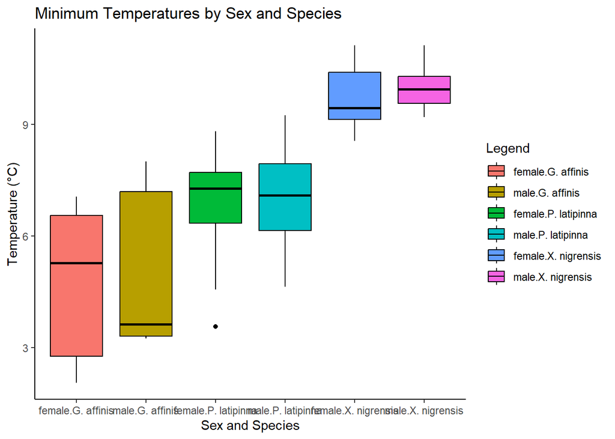

```r
# repeat for min temperature, and Ttot
all_boxplot2 <- ggplot(data = rawdata_1,
                             aes(x = interaction(Sex, Species),
                                 y = CTmin.C,
                                 fill = interaction(Sex, Species))) +
  geom_boxplot(color = "black") +
  labs(
    title = "Minimum Temperatures by Sex and Species",
    x = "Sex and Species",
    y = "Temperature (°C)",
    fill = "Legend"
  ) +
  theme_classic()

print(all_boxplot2)
```

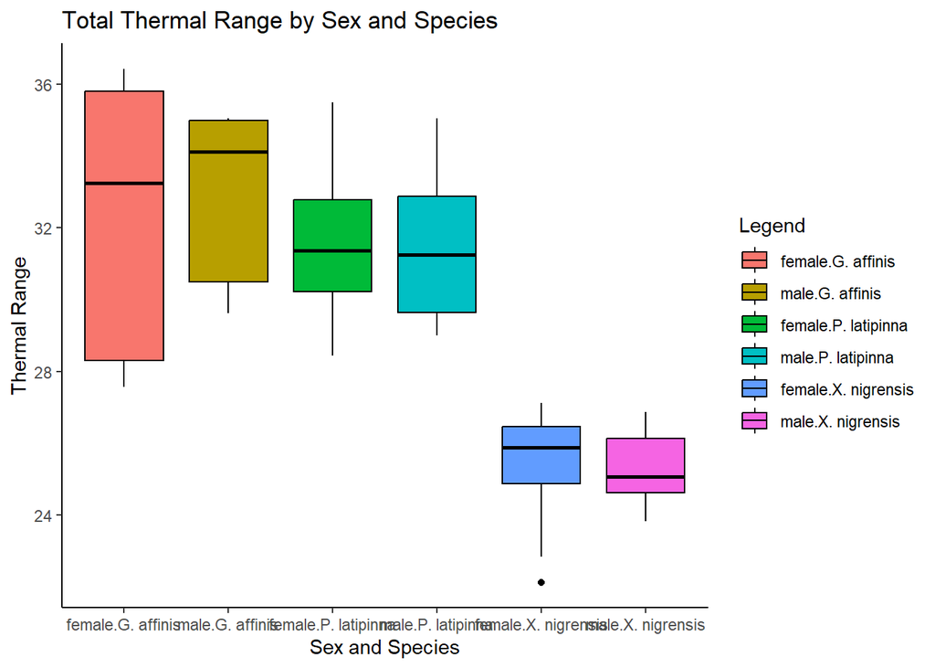

```r
all_boxplot3 <- ggplot(data = rawdata_1,
                             aes(x = interaction(Sex, Species),
                                 y = T.tot,
                                 fill = interaction(Sex, Species))) +
  geom_boxplot(color = "black") +
  labs(
    title = "Total Thermal Range by Sex and Species",
    x = "Sex and Species",
    y = "Thermal Range",
    fill = "Legend"
  ) +
  theme_classic()

print(all_boxplot3)
```

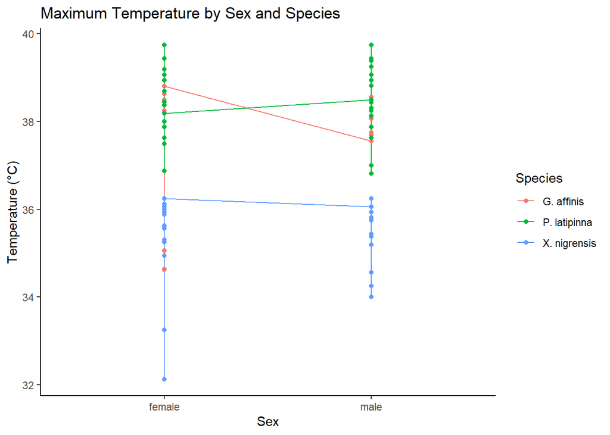

```r
#create a line plot showing temperature by sex AND species
library(ggplot2)
all_lineplot1 <- ggplot(data = rawdata_1,
                        aes(x = factor(Sex),
                            y = CTmax.C,
                            group = Species,
                            color = Species)) +
  geom_line() +
  geom_point() +
  labs(
    title = "Maximum Temperature by Sex and Species",
    x = "Sex",
    y = "Temperature (°C)") +
  theme_classic()

print(all_lineplot1)
```

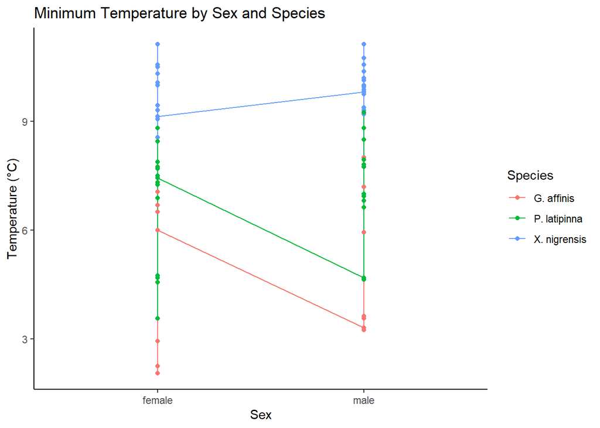

```r
# repeat for min temperature, and Ttot
all_lineplot2 <- ggplot(data = rawdata_1,
                        aes(x = factor(Sex),
                            y = CTmin.C,
                            group = Species,
                            color = Species)) +
  geom_line() +
  geom_point() +
  labs(
    title = "Minimum Temperature by Sex and Species",
    x = "Sex",
    y = "Temperature (°C)") +
  theme_classic()

print(all_lineplot2)
```

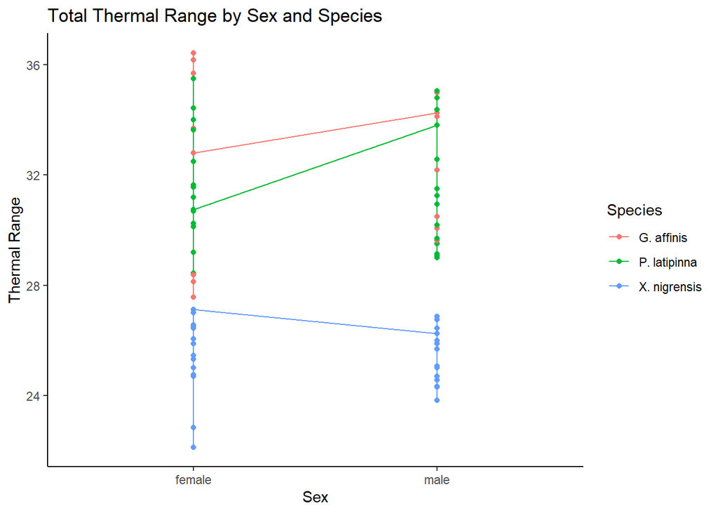

```r
all_lineplot3 <- ggplot(data = rawdata_1,
                        aes(x = factor(Sex),
                            y = T.tot,
                            group = Species,
                            color = Species)) +
  geom_line() +
  geom_point() +
  labs(
    title = "Total Thermal Range by Sex and Species",
    x = "Sex",
    y = "Thermal Range") +
  theme_classic()

print(all_lineplot3)
```

Now that you’ve done basic statistics, how does your data look? Write about the trends you see below.

## Comparisons

In our analysis, we want to answer the following questions:

1. How do males and females differ in their max, min and overall thermal tolerance?
2. How do the species differ? Do males and females only differ in particular species?
3. How do courting species differ from non-courting species? Is there a difference regardless of sex? Is there a difference between the two types of males even within the same species (eg swordtails)?

### Normality check

Before we begin, we need to check if our data follows a normal distribution. A lot of the parametric tests (t-tests, ANOVAs, etc) have normality as a requirement, so we need confirm our data fits this. If not, we might need to transform the data or perform non-parametric tests.

You will need to check for normality across the entire dataset. We will do this three ways: using a Shariro-Wilke test, histograms, and QQ plots.

For this you will use: dplyr package, shapiro.test(), hist(), qqnorm(), and qqline()

- For more info on the Shapiro-Wilke tests, see: https://www.statology.org/shapiro-wilk-test-r/
- For more info on histograms, see: https://www.datamentor.io/r-programming/histogram
- For more info on QQ plots, see: http://www.sthda.com/english/wiki/qq-plots-quantile-quantile-plots-r-base-graphs

```r
#perform SW tests for entire dataset
library(dplyr)
shapiro.test(rawdata_1$CTmax.C)
```

```
##
##  Shapiro-Wilk normality test
##
## data:  rawdata_1$CTmax.C
## W = 0.94199, p-value = 0.001337
```

```r
shapiro.test(rawdata_1$CTmin.C)
```

```
##
##  Shapiro-Wilk normality test
##
## data:  rawdata_1$CTmin.C
## W = 0.93528, p-value = 0.0005928
```

```r
shapiro.test(rawdata_1$T.tot)
```

```
##
##  Shapiro-Wilk normality test
##
## data:  rawdata_1$T.tot
## W = 0.95666, p-value = 0.009034
```

```r
shapiro.test(rawdata_1$Size.mm)
```

```
##
##  Shapiro-Wilk normality test
##
## data:  rawdata_1$Size.mm
## W = 0.92219, p-value = 0.0001334
```

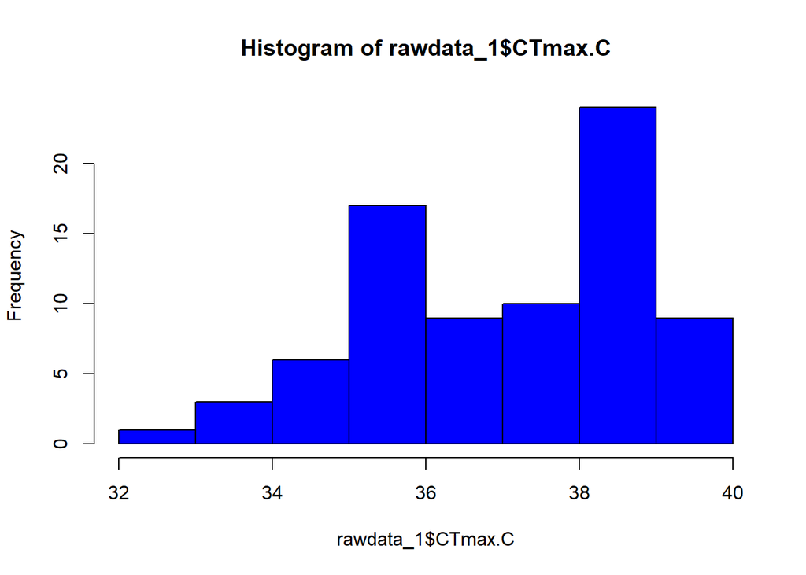

```r
#Create histogram for entire dataset
hist(rawdata_1$CTmax.C, col = 'blue')
```

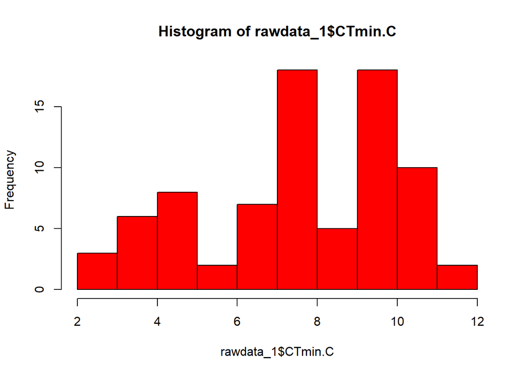

```r
hist(rawdata_1$CTmin.C, col = 'red')
```

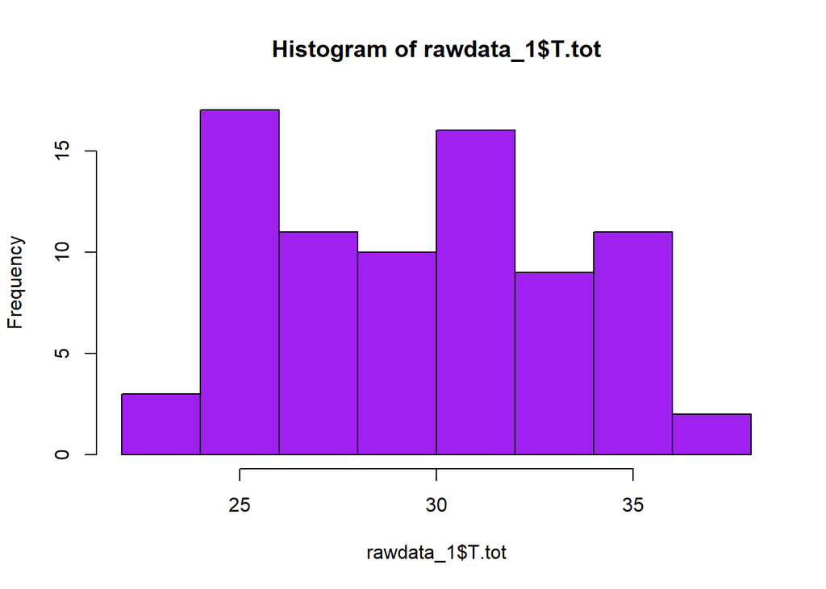

```r
hist(rawdata_1$T.tot, col = 'purple')
```

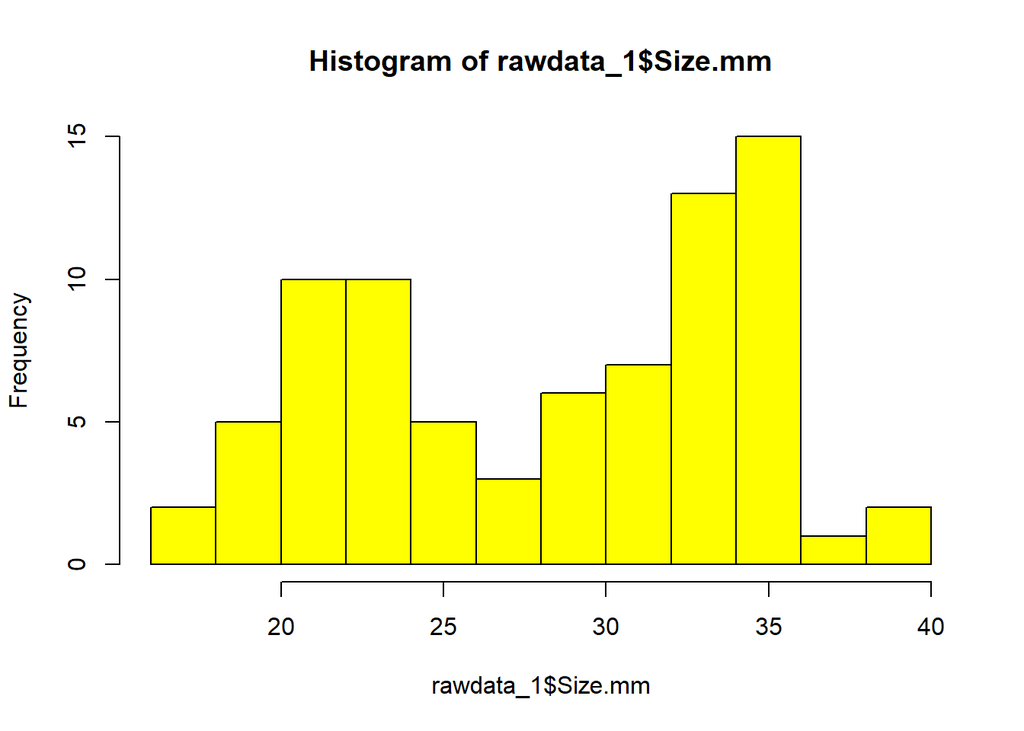

```r
hist(rawdata_1$Size.mm, col = 'yellow')
```

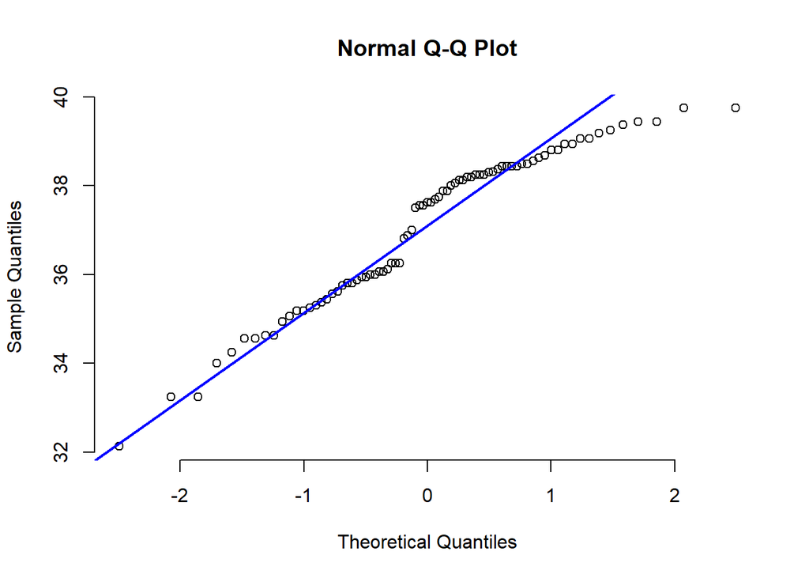

```r
#Create QQplot for entire dataset
qqnorm(rawdata_1$CTmax.C, pch = 1, frame = FALSE)
qqline(rawdata_1$CTmax.C, col = "blue", lwd = 2)
```

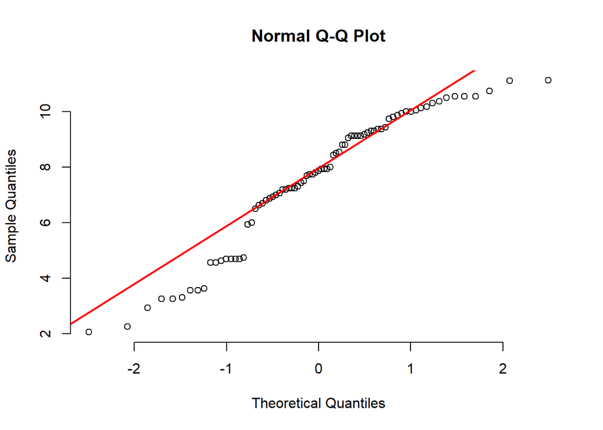

```r
qqnorm(rawdata_1$CTmin.C, pch = 1, frame = FALSE)
qqline(rawdata_1$CTmin.C, col = "red", lwd = 2)
```

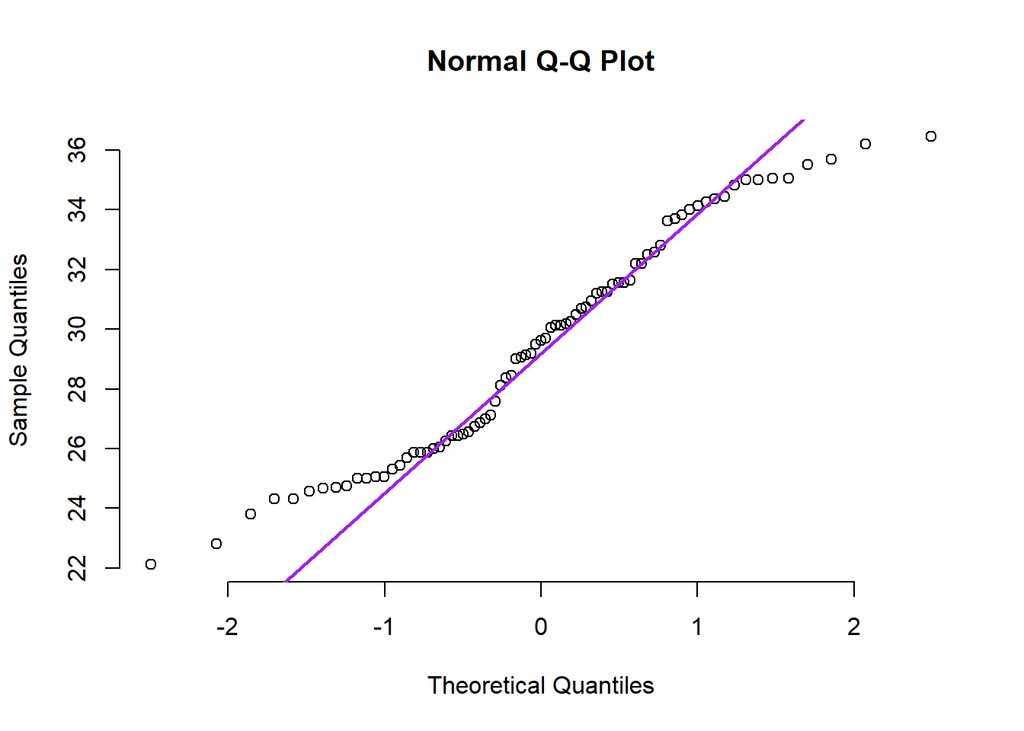

```r
qqnorm(rawdata_1$T.tot, pch = 1, frame = FALSE)
qqline(rawdata_1$T.tot, col = "purple", lwd = 2)
```

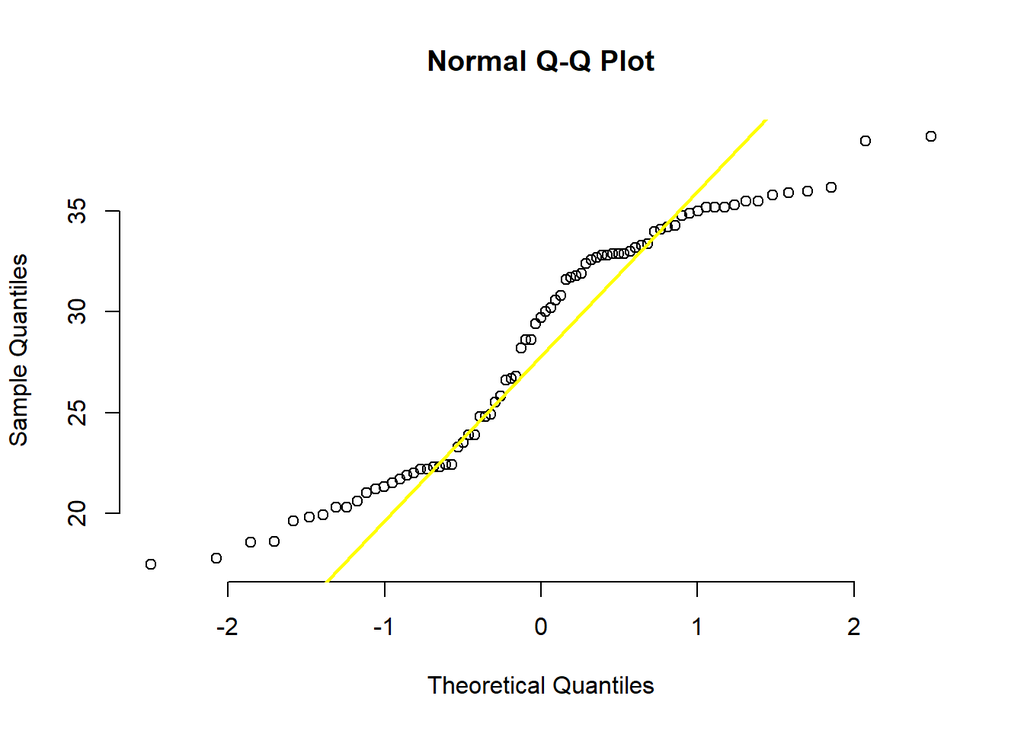

```r
qqnorm(rawdata_1$Size.mm, pch = 1, frame = FALSE)
qqline(rawdata_1$Size.mm, col = "yellow", lwd = 2)
```

How does your data look? Normal, sorta normal, super not normal? Write about the trends you see below.

### Analysis

To address our questions, we will first examine our data in small chunks (within species), then take a look at the whole picture (between species) using mixed effects models.

NOTE: if the data was not normal, we need to transform it before continuing. Typical transformations include log or square root transformations. Transform data, and retest for normality. You can ignore this if the data was normal.

```r
## log transformation
log_CTmax <- log(rawdata_1$CTmax.C, base = 10)
log_CTmin <- log(rawdata_1$CTmin.C, base = 10)
log_T.tot <- log(rawdata_1$T.tot, base = 10)
log_size.mm <- log(rawdata_1$Size.mm, base = 10)

## sqrt transformation
sqrt_CTmax <- sqrt(rawdata_1$CTmax.C)
sqrt_CTmin <- sqrt(rawdata_1$CTmin.C)
sqrt_T.tot <- sqrt(rawdata_1$T.tot)
sqrt_size.mm <- sqrt(rawdata_1$Size.mm)

## cube root transformation
cube_CTmax <- '^'(rawdata_1$CTmax.C, 1/3)
cube_CTmin <- '^'(rawdata_1$CTmin.C, 1/3)
cube_T.tot <-'^'(rawdata_1$T.tot, 1/3)
cube_size.mm <- '^'(rawdata_1$Size.mm, 1/3)


#redo SW test
shapiro.test(log_CTmax)
```

```
##
##  Shapiro-Wilk normality test
##
## data:  log_CTmax
## W = 0.93643, p-value = 0.0006794
```

```r
shapiro.test(log_CTmin)
```

```
##
##  Shapiro-Wilk normality test
##
## data:  log_CTmin
## W = 0.85674, p-value = 3.144e-07
```

```r
shapiro.test(log_T.tot)
```

```
##
##  Shapiro-Wilk normality test
##
## data:  log_T.tot
## W = 0.95845, p-value = 0.01154
```

```r
shapiro.test(log_size.mm)
```

```
##
##  Shapiro-Wilk normality test
##
## data:  log_size.mm
## W = 0.91359, p-value = 5.325e-05
```

```r
shapiro.test(sqrt_CTmax)
```

```
##
##  Shapiro-Wilk normality test
##
## data:  sqrt_CTmax
## W = 0.93935, p-value = 0.0009664
```

```r
shapiro.test(sqrt_CTmin)
```

```
##
##  Shapiro-Wilk normality test
##
## data:  sqrt_CTmin
## W = 0.90385, p-value = 1.985e-05
```

```r
shapiro.test(sqrt_T.tot)
```

```
##
##  Shapiro-Wilk normality test
##
## data:  sqrt_T.tot
## W = 0.95817, p-value = 0.01111
```

```r
shapiro.test(sqrt_size.mm)
```

```
##
##  Shapiro-Wilk normality test
##
## data:  sqrt_size.mm
## W = 0.91879, p-value = 9.219e-05
```

```r
shapiro.test(cube_CTmax)
```

```
##
##  Shapiro-Wilk normality test
##
## data:  cube_CTmax
## W = 0.9384, p-value = 0.000862
```

```r
shapiro.test(cube_CTmin)
```

```
##
##  Shapiro-Wilk normality test
##
## data:  cube_CTmin
## W = 0.88994, p-value = 5.288e-06
```

```r
shapiro.test(cube_T.tot)
```

```
##
##  Shapiro-Wilk normality test
##
## data:  cube_T.tot
## W = 0.9584, p-value = 0.01147
```

```r
shapiro.test(cube_size.mm)
```

```
##
##  Shapiro-Wilk normality test
##
## data:  cube_size.mm
## W = 0.91726, p-value = 7.832e-05
```

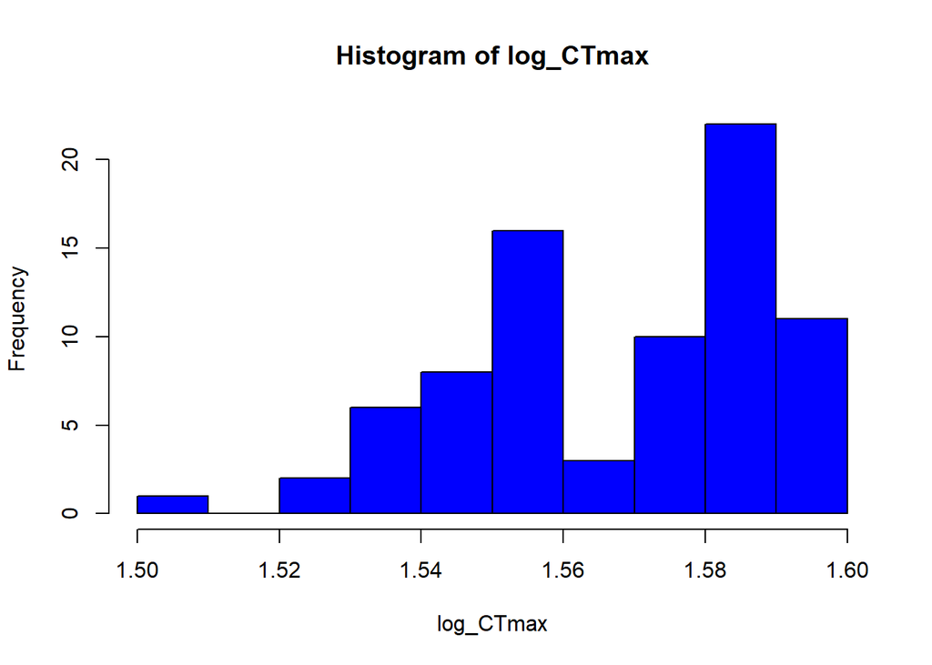

```r
#redo histogram
hist(log_CTmax, col = 'blue')
```

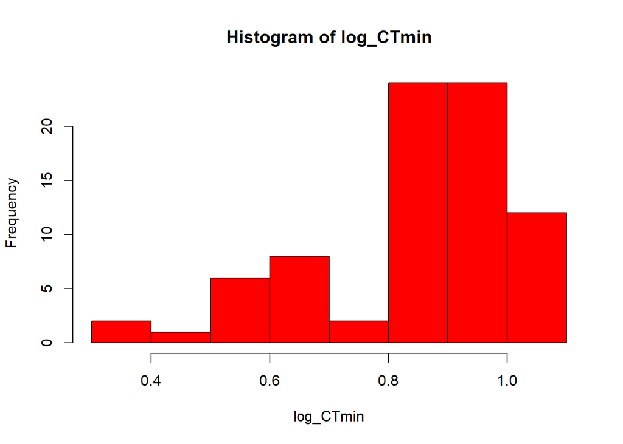

```r
hist(log_CTmin, col = 'red')
```

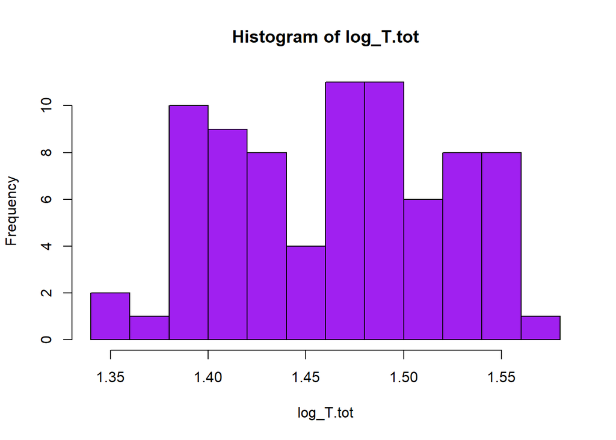

```r
hist(log_T.tot, col = 'purple')
```

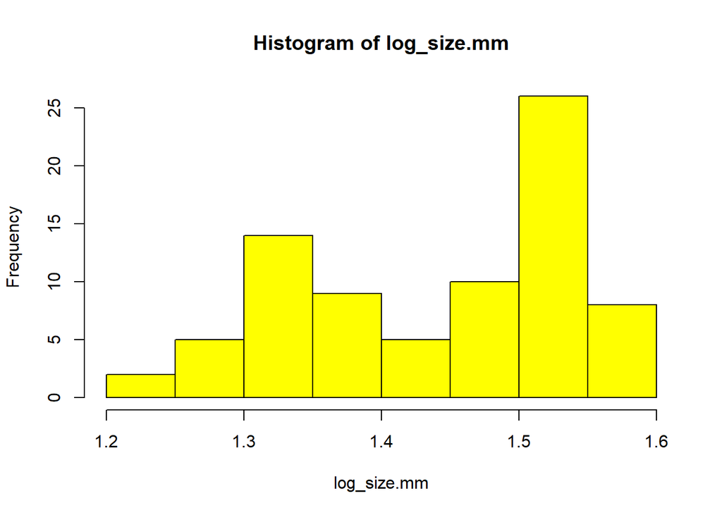

```r
hist(log_size.mm, col = 'yellow')
```

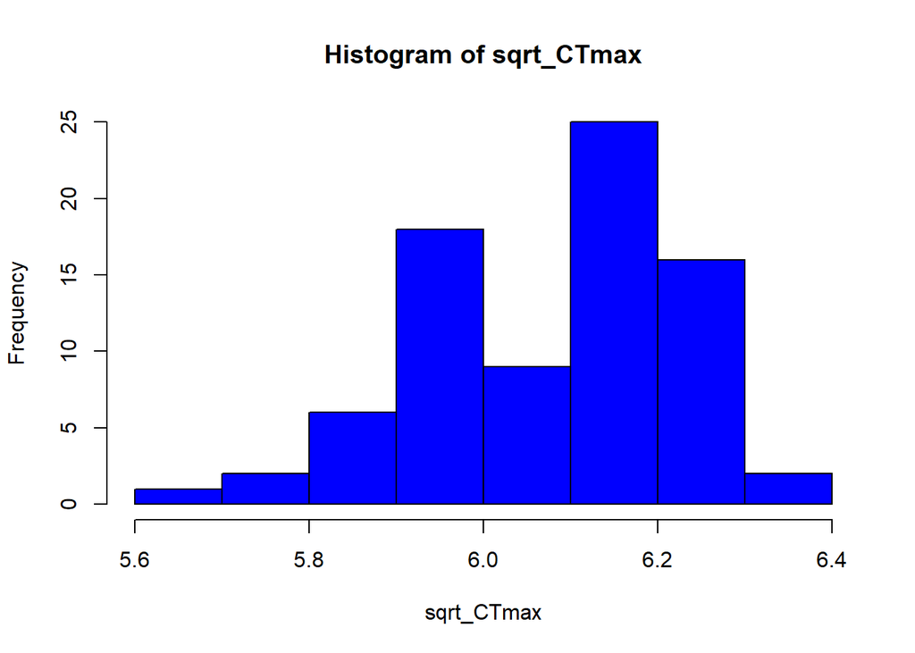

```r
hist(sqrt_CTmax, col = 'blue')
```

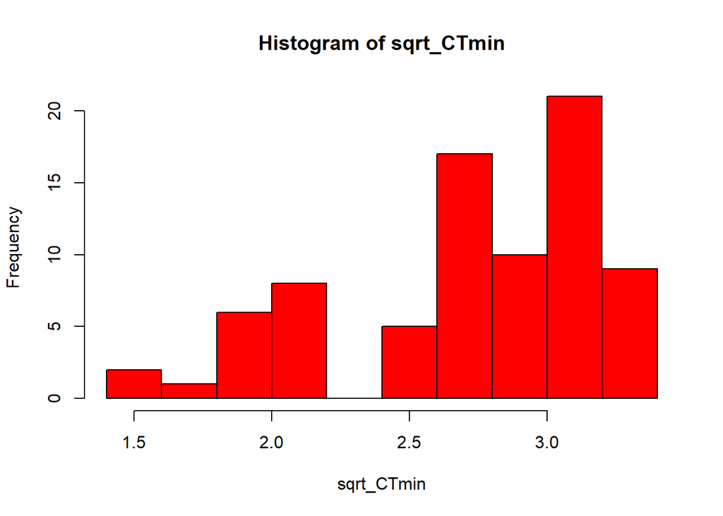

```r
hist(sqrt_CTmin, col = 'red')
```